# Module 11

#### Hemi-module gene counts:

200 probesets in hemi-module A.  
130 probesets in hemi-module B.  
Note: While the mapping of probesets to genes is usually one-to-one, some genes are targeted by multiple probesets, some probesets target multiple genes, and some probesets do not target any genes (i.e., the region of the genome they match is no longer considered genic).

#### Contrast SVE:

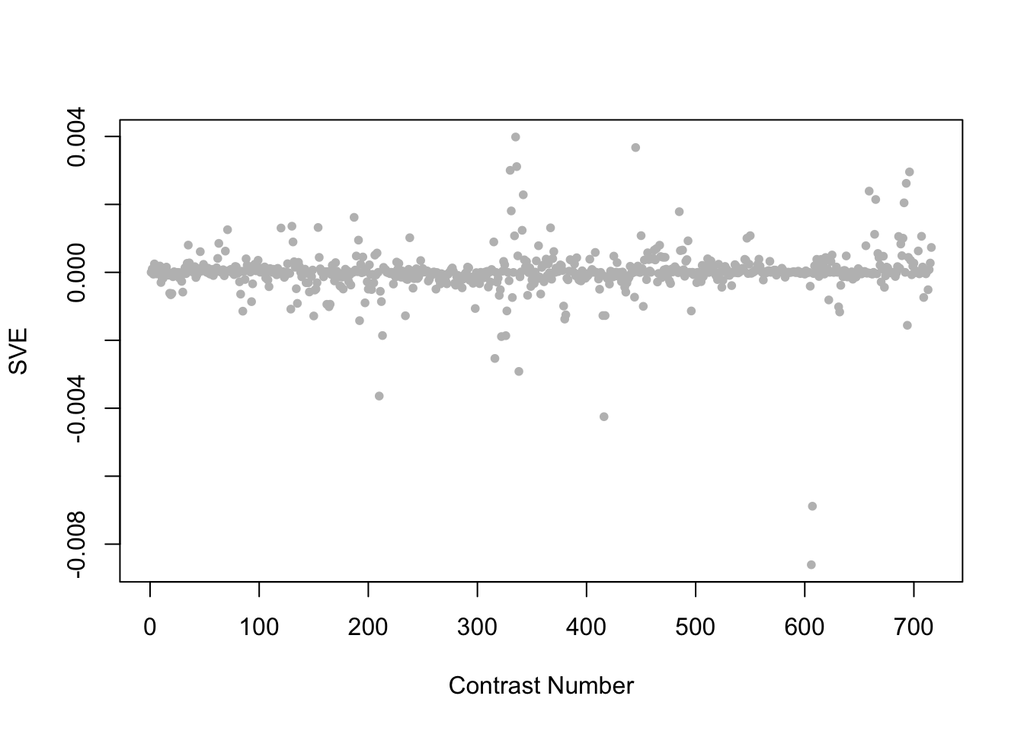

Positive SVE Contrasts:

|  | Contrast.Num | SVE | GEO.GSE | Cond.1 | Cond.2 | Mutation |
| --- | --- | --- | --- | --- | --- | --- |
| GSE38997.s3t2.vs.s2t2 | 335 | 0.00 | GSE38997 | experiment 4 UVC- and EtBr-exposed samples at 24 h 4eu24 | experiment 4 EtBr-exposed samples at 24 h 4e24 |  |
| GSE27677B.s0t9.vs.s0t7 | 445 | 0.00 | GSE27677 | N2, Fed 48 h, rep 1 | N2, Fed 24 h, rep 1 |  |
| GSE38997.s4t2.vs.s2t2 | 336 | 0.00 | GSE38997 | experiment 4 UVC-exposed samples at 24 h 4u24 | experiment 4 EtBr-exposed samples at 24 h 4e24 |  |
| GSE38997.s4t4.vs.s2t4 | 330 | 0.00 | GSE38997 | experiment 1 UVC-exposed samples at 51 h 1u51 | experiment 1 EtBr-exposed samples at 51 h 1e51 |  |
| GSE11055.s1t7.vs.s5t7 | 696 | 0.00 | GSE11055 | L1-L2 larvae 15 hr after hatching in the presence of food | L1 larvae starved for 12 hr after hatching and then fed for 3 hr |  |

Negative SVE Contrasts:

|  | Contrast.Num | SVE | GEO.GSE | Cond.1 | Cond.2 | Mutation |
| --- | --- | --- | --- | --- | --- | --- |
| GSE21784.s1t1.vs.s3t1 | 606 | -0.01 | GSE21784 | L4 larvae, biological rep1 | day 15 adults, biological rep 1 |  |
| GSE21784.s1t1.vs.s2t1 | 607 | -0.01 | GSE21784 | L4 larvae, biological rep1 | day 6 adults, biological rep 1 |  |
| GSE29951.s0t2.vs.s0t1 | 416 | -0.00 | GSE29951 | C.elegans wild type raised in the presence of Cd, rep1 | C.elegans wild type raised in the absence of Cd, rep1 |  |
| GSE42689.s3t1.vs.s1t1 | 210 | -0.00 | GSE42689 | mlk-1 fasted 1 | mek-1 fasted 1 |  |
| GSE38997.s2t1.vs.s1t1 | 338 | -0.00 | GSE38997 | experiment 4 EtBr-exposed samples at 3 h 4e3 | experiment 4 control samples at 3 h 4c3 |  |

$~$

#### Contrast SVE, Up-Regulated Genes Only:

Calculating SVE for up-regulated and down-regulated genes separately may be more informative in many cases than projecting the up- and down- gene sets together. This is due to the fact that the weight distribution of many modules is highly skewed, indicating that only one of the hemi-modules may be biologically meaningful (i.e., a set of genes are strongly correlated by only a few genes (or none) are strongly anti-correlated to that set.)

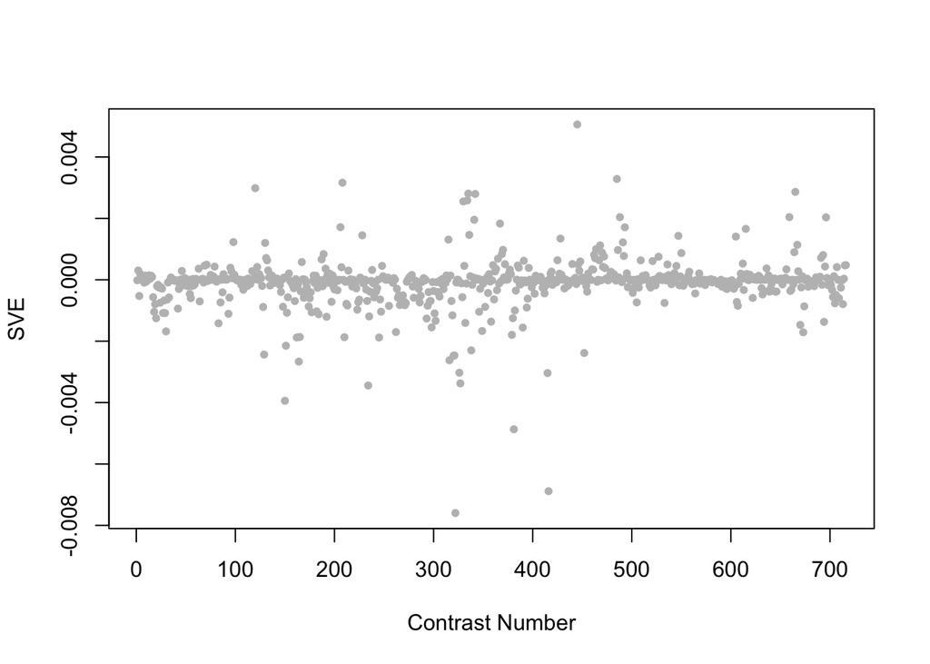

Positive SVE Contrasts:

|  | Contrast.Num | SVE | GEO.GSE | Cond.1 | Cond.2 | Mutation |
| --- | --- | --- | --- | --- | --- | --- |
| GSE27677B.s0t9.vs.s0t7 | 445 | 0.01 | GSE27677 | N2, Fed 48 h, rep 1 | N2, Fed 24 h, rep 1 |  |
| GSE23528A.s0t5.vs.s0t1 | 485 | 0.00 | GSE23528 | Adult at T18, non-entrained control time-series experiment 4 | Adult at T2, non-entrained control time-series experiment 4 |  |
| GSE42703.s2t2.vs.s2t1 | 208 | 0.00 | GSE42703 | WT incubated with H2O, biological rep1 | WT incubated with 1mM copper sulfate, biological rep1 |  |
| GSE54024.s3t1.vs.s4t1 | 120 | 0.00 | GSE54024 | nuo-6(qm200) young adults, biological rep 1 | isp-1(qm150) young adults, biological rep 1 |  |
| GSE15159.s1t2.vs.s1t1 | 665 | 0.00 | GSE15159 | glp-1_UV_2007_rep1 | glp-1_control_2007_rep1 |  |

Negative SVE Contrasts:

|  | Contrast.Num | SVE | GEO.GSE | Cond.1 | Cond.2 | Mutation |
| --- | --- | --- | --- | --- | --- | --- |
| GSE38997.s4t3.vs.s1t3 | 322 | -0.01 | GSE38997 | experiment 1 UVC-exposed samples at 48 h 1u48 | experiment 1 control samples at 48 h 1c48 |  |
| GSE29951.s0t2.vs.s0t1 | 416 | -0.01 | GSE29951 | C.elegans wild type raised in the presence of Cd, rep1 | C.elegans wild type raised in the absence of Cd, rep1 |  |
| GSE34471.s0t2.vs.s0t1 | 381 | -0.00 | GSE34471 | 20uM-Con-1 | 4uM-Con-1 |  |
| GSE47778.s2t1.vs.s3t1 | 150 | -0.00 | GSE47778 | daf-2; replicate 1 | daf-16; replicate 1 | daf-2 vs. daf-16 |
| GSE42592B.s3t3.vs.s3t2 | 234 | -0.00 | GSE42592 | cadmium_high_expose-8h_rep1 | cadmium_high_expose-4h_rep1 |  |

$~$

#### Contrast SVE, Down-Regulated Genes Only:

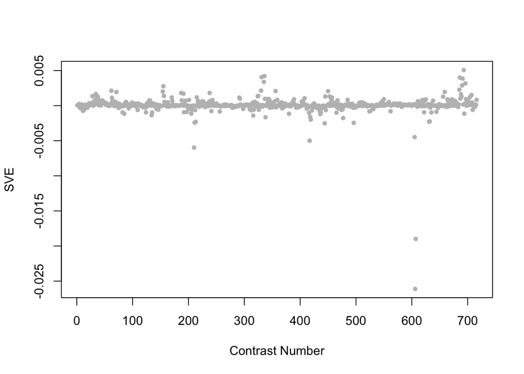

Positive SVE Contrasts:

|  | Contrast.Num | SVE | GEO.GSE | Cond.1 | Cond.2 | Mutation |
| --- | --- | --- | --- | --- | --- | --- |
| GSE11055.s1t7.vs.s2t7 | 693 | 0.01 | GSE11055 | L1-L2 larvae 15 hr after hatching in the presence of food | L1 larvae 15 hr after hatching in the absence of food |  |
| GSE38997.s4t2.vs.s2t2 | 336 | 0.00 | GSE38997 | experiment 4 UVC-exposed samples at 24 h 4u24 | experiment 4 EtBr-exposed samples at 24 h 4e24 |  |
| GSE38997.s4t4.vs.s3t4 | 331 | 0.00 | GSE38997 | experiment 1 UVC-exposed samples at 51 h 1u51 | experiment 1 UVC- and EtBr-exposed samples at 51 h 1eu51 |  |
| GSE12298C.s1t1.vs.s0t1 | 686 | 0.00 | GSE12298 | mefloquine_low_dose-rep1 | mefloquine_control-rep1 |  |
| GSE11055.s4t7.vs.s2t7 | 691 | 0.00 | GSE11055 | L1 larvae fed for 12 hr after hatching and then starved for 3 hr | L1 larvae 15 hr after hatching in the absence of food |  |

Negative SVE Contrasts:

|  | Contrast.Num | SVE | GEO.GSE | Cond.1 | Cond.2 | Mutation |
| --- | --- | --- | --- | --- | --- | --- |
| GSE21784.s1t1.vs.s3t1 | 606 | -0.03 | GSE21784 | L4 larvae, biological rep1 | day 15 adults, biological rep 1 |  |
| GSE21784.s1t1.vs.s2t1 | 607 | -0.02 | GSE21784 | L4 larvae, biological rep1 | day 6 adults, biological rep 1 |  |
| GSE42689.s3t1.vs.s1t1 | 210 | -0.01 | GSE42689 | mlk-1 fasted 1 | mek-1 fasted 1 |  |
| GSE28856.s0t2.vs.s0t1 | 417 | -0.01 | GSE28856 | Wild-type 1 h after shifting temperature rep1 | Wild-type 0 h after shifting temperature rep1 |  |
| GSE21784.s2t1.vs.s3t1 | 605 | -0.00 | GSE21784 | day 6 adults, biological rep 1 | day 15 adults, biological rep 1 |  |

$~$

$~$

#### GO Term Enrichment:

This analysis tests each hemi-module for enrichment of specific GO terms. Only gene-level annotations (e.g., as would be found on the gene’s page in Wormbase) are tested - the hierarchical structure of the GO ontology is not taken into account.

*Note: At least the top two most enriched terms from each GO domain (BP/MF/CC) are shown, even when not statistically significant.*

##### Enriched GO terms: Hemi-module A

| ID | GO.Term | GO Domain | Raw p-value | Adj p-value |
| --- | --- | --- | --- | --- |
| [GO_0006896](http://amigo.geneontology.org/amigo/term/GO:0006896) | Golgi to vacuole transport | BP | 1.02e-03 | 9.95e-01 |
| [GO_0006623](http://amigo.geneontology.org/amigo/term/GO:0006623) | protein targeting to vacuole | BP | 1.89e-03 | 9.95e-01 |
| [GO_0004300](http://amigo.geneontology.org/amigo/term/GO:0004300) | enoyl-CoA hydratase activity | MF | 1.43e-03 | 9.97e-01 |
| [GO_0005516](http://amigo.geneontology.org/amigo/term/GO:0005516) | calmodulin binding | MF | 5.93e-03 | 9.97e-01 |
| [GO_0005884](http://amigo.geneontology.org/amigo/term/GO:0005884) | actin filament | CC | 4.36e-03 | 9.96e-01 |
| [GO_0098830](http://amigo.geneontology.org/amigo/term/GO:0098830) | presynaptic endosome | CC | 8.39e-03 | 9.96e-01 |

##### Enriched GO terms: Hemi-module B

| ID | GO.Term | GO Domain | Raw p-value | Adj p-value |
| --- | --- | --- | --- | --- |
| [GO_0043053](http://amigo.geneontology.org/amigo/term/GO:0043053) | dauer entry | BP | 2.86e-03 | 9.98e-01 |
| [GO_0043413](http://amigo.geneontology.org/amigo/term/GO:0043413) | macromolecule glycosylation | BP | 4.37e-03 | 9.98e-01 |
| [GO_0008107](http://amigo.geneontology.org/amigo/term/GO:0008107) | galactoside 2-alpha-L-fucosyltransferase activity | MF | 3.97e-03 | 1.00e+00 |
| [GO_0005229](http://amigo.geneontology.org/amigo/term/GO:0005229) | intracellular calcium activated chloride channel activity | MF | 4.74e-03 | 1.00e+00 |
| [GO_0098894](http://amigo.geneontology.org/amigo/term/GO:0098894) | extrinsic component of presynaptic endocytic zone membrane | CC | 4.74e-03 | 1.00e+00 |
| [GO_0001726](http://amigo.geneontology.org/amigo/term/GO:0001726) | ruffle | CC | 1.88e-02 | 1.00e+00 |

$~$

$~$

#### Tissue Enrichment:

This analysis tests each hemi-module for enrichment of genes associated with anatomy terms. Negative enrichment scores indicate fewer hemi-module genes than expected by random chance were associated with the anatomy term in question.

##### Enriched tissues: Hemi-module A

No significant annotations.

##### Enriched tissues: Hemi-module B

No significant annotations.

$~$

$~$

#### HOMER promoter motif enrichment:

This analysis tests each hemi-module for enrichment of 108 known *C. elegans* transcription factor binding site motifs (see [108 CE motifs](https://katiepod.github.io//all.worm.motifs.html)) using the HOMER (Hypergeometric Optimization of Motif EnRichment) software (see [PMID:20513432](https://pubmed.ncbi.nlm.nih.gov/20513432)). HOMER was run using default parameters on sequences 1 kb upstream of the transcription start site.

##### Motif enrichment: Hemi-module A

Total target sequences = 154  
Total background sequences = 40566  
* - possible false positive

Rank

Motif

P-value

log P-pvalue

% of Targets

% of Background

STD(Bg STD)

Best Match/Details

Motif File

1 *

[figure not shown]

1e-11

-2.718e+01

6.49%

0.19%

281.3bp (332.2bp)

elt-2/MA1701.1/Jaspar(0.762)  
[More Information](https://katiepod.github.io/HomerResults/m11_a_hemi_genes.txt.out.1kb/homerResults/motif1.info.html) | [Similar Motifs Found](https://katiepod.github.io/HomerResults/m11_a_hemi_genes.txt.out.1kb/homerResults/motif1.similar.html)

[motif file (matrix)](https://katiepod.github.io/HomerResults/m11_a_hemi_genes.txt.out.1kb/homerResults/motif1.motif)

2 *

[figure not shown]

1e-10

-2.449e+01

5.84%

0.18%

284.4bp (270.5bp)

SD0002.1_at_AC_acceptor/Jaspar(0.539)  
[More Information](https://katiepod.github.io/HomerResults/m11_a_hemi_genes.txt.out.1kb/homerResults/motif2.info.html) | [Similar Motifs Found](https://katiepod.github.io/HomerResults/m11_a_hemi_genes.txt.out.1kb/homerResults/motif2.similar.html)

[motif file (matrix)](https://katiepod.github.io/HomerResults/m11_a_hemi_genes.txt.out.1kb/homerResults/motif2.motif)

3 *

[figure not shown]

1e-10

-2.316e+01

13.64%

2.28%

335.5bp (306.7bp)

mab-3/MA0262.1/Jaspar(0.600)  
[More Information](https://katiepod.github.io/HomerResults/m11_a_hemi_genes.txt.out.1kb/homerResults/motif3.info.html) | [Similar Motifs Found](https://katiepod.github.io/HomerResults/m11_a_hemi_genes.txt.out.1kb/homerResults/motif3.similar.html)

[motif file (matrix)](https://katiepod.github.io/HomerResults/m11_a_hemi_genes.txt.out.1kb/homerResults/motif3.motif)

4 *

[figure not shown]

1e-9

-2.284e+01

9.09%

0.85%

320.5bp (306.4bp)

fkh-9/MA1440.1/Jaspar(0.770)  
[More Information](https://katiepod.github.io/HomerResults/m11_a_hemi_genes.txt.out.1kb/homerResults/motif4.info.html) | [Similar Motifs Found](https://katiepod.github.io/HomerResults/m11_a_hemi_genes.txt.out.1kb/homerResults/motif4.similar.html)

[motif file (matrix)](https://katiepod.github.io/HomerResults/m11_a_hemi_genes.txt.out.1kb/homerResults/motif4.motif)

5 *

[figure not shown]

1e-9

-2.209e+01

3.90%

0.04%

185.5bp (370.5bp)

MF0008.1_MADS_class/Jaspar(0.539)  
[More Information](https://katiepod.github.io/HomerResults/m11_a_hemi_genes.txt.out.1kb/homerResults/motif5.info.html) | [Similar Motifs Found](https://katiepod.github.io/HomerResults/m11_a_hemi_genes.txt.out.1kb/homerResults/motif5.similar.html)

[motif file (matrix)](https://katiepod.github.io/HomerResults/m11_a_hemi_genes.txt.out.1kb/homerResults/motif5.motif)

6 *

[figure not shown]

1e-9

-2.188e+01

11.69%

1.73%

210.6bp (312.8bp)

pha-4/MA0546.1/Jaspar(0.699)  
[More Information](https://katiepod.github.io/HomerResults/m11_a_hemi_genes.txt.out.1kb/homerResults/motif6.info.html) | [Similar Motifs Found](https://katiepod.github.io/HomerResults/m11_a_hemi_genes.txt.out.1kb/homerResults/motif6.similar.html)

[motif file (matrix)](https://katiepod.github.io/HomerResults/m11_a_hemi_genes.txt.out.1kb/homerResults/motif6.motif)

7 *

[figure not shown]

1e-9

-2.100e+01

7.14%

0.51%

243.5bp (317.6bp)

POL012.1_TATA-Box/Jaspar(0.536)  
[More Information](https://katiepod.github.io/HomerResults/m11_a_hemi_genes.txt.out.1kb/homerResults/motif7.info.html) | [Similar Motifs Found](https://katiepod.github.io/HomerResults/m11_a_hemi_genes.txt.out.1kb/homerResults/motif7.similar.html)

[motif file (matrix)](https://katiepod.github.io/HomerResults/m11_a_hemi_genes.txt.out.1kb/homerResults/motif7.motif)

8 *

[figure not shown]

1e-8

-2.012e+01

7.14%

0.55%

240.7bp (313.6bp)

elt-6/MA1439.1/Jaspar(0.648)  
[More Information](https://katiepod.github.io/HomerResults/m11_a_hemi_genes.txt.out.1kb/homerResults/motif8.info.html) | [Similar Motifs Found](https://katiepod.github.io/HomerResults/m11_a_hemi_genes.txt.out.1kb/homerResults/motif8.similar.html)

[motif file (matrix)](https://katiepod.github.io/HomerResults/m11_a_hemi_genes.txt.out.1kb/homerResults/motif8.motif)

9 *

[figure not shown]

1e-8

-1.990e+01

5.19%

0.21%

327.1bp (284.0bp)

lin-54/MA1450.1/Jaspar(0.556)  
[More Information](https://katiepod.github.io/HomerResults/m11_a_hemi_genes.txt.out.1kb/homerResults/motif9.info.html) | [Similar Motifs Found](https://katiepod.github.io/HomerResults/m11_a_hemi_genes.txt.out.1kb/homerResults/motif9.similar.html)

[motif file (matrix)](https://katiepod.github.io/HomerResults/m11_a_hemi_genes.txt.out.1kb/homerResults/motif9.motif)

10 *

[figure not shown]

1e-8

-1.898e+01

6.49%

0.47%

253.8bp (294.2bp)

POL010.1_DCE_S_III/Jaspar(0.575)  
[More Information](https://katiepod.github.io/HomerResults/m11_a_hemi_genes.txt.out.1kb/homerResults/motif10.info.html) | [Similar Motifs Found](https://katiepod.github.io/HomerResults/m11_a_hemi_genes.txt.out.1kb/homerResults/motif10.similar.html)

[motif file (matrix)](https://katiepod.github.io/HomerResults/m11_a_hemi_genes.txt.out.1kb/homerResults/motif10.motif)

11 *

[figure not shown]

1e-8

-1.891e+01

5.19%

0.24%

233.0bp (292.0bp)

PL0012.1_hlh-2::hlh-8/Jaspar(0.514)  
[More Information](https://katiepod.github.io/HomerResults/m11_a_hemi_genes.txt.out.1kb/homerResults/motif11.info.html) | [Similar Motifs Found](https://katiepod.github.io/HomerResults/m11_a_hemi_genes.txt.out.1kb/homerResults/motif11.similar.html)

[motif file (matrix)](https://katiepod.github.io/HomerResults/m11_a_hemi_genes.txt.out.1kb/homerResults/motif11.motif)

12 *

[figure not shown]

1e-7

-1.738e+01

7.14%

0.73%

228.8bp (308.2bp)

MF0005.1_Forkhead_class/Jaspar(0.624)  
[More Information](https://katiepod.github.io/HomerResults/m11_a_hemi_genes.txt.out.1kb/homerResults/motif12.info.html) | [Similar Motifs Found](https://katiepod.github.io/HomerResults/m11_a_hemi_genes.txt.out.1kb/homerResults/motif12.similar.html)

[motif file (matrix)](https://katiepod.github.io/HomerResults/m11_a_hemi_genes.txt.out.1kb/homerResults/motif12.motif)

13 *

[figure not shown]

1e-7

-1.697e+01

9.09%

1.37%

229.1bp (306.3bp)

MF0008.1_MADS_class/Jaspar(0.461)  
[More Information](https://katiepod.github.io/HomerResults/m11_a_hemi_genes.txt.out.1kb/homerResults/motif13.info.html) | [Similar Motifs Found](https://katiepod.github.io/HomerResults/m11_a_hemi_genes.txt.out.1kb/homerResults/motif13.similar.html)

[motif file (matrix)](https://katiepod.github.io/HomerResults/m11_a_hemi_genes.txt.out.1kb/homerResults/motif13.motif)

14 *

[figure not shown]

1e-7

-1.631e+01

3.90%

0.13%

310.1bp (247.5bp)

PHA-4(Forkhead)/cElegans-Embryos-PHA4-ChIP-Seq(modEncode)/Homer(0.554)  
[More Information](https://katiepod.github.io/HomerResults/m11_a_hemi_genes.txt.out.1kb/homerResults/motif14.info.html) | [Similar Motifs Found](https://katiepod.github.io/HomerResults/m11_a_hemi_genes.txt.out.1kb/homerResults/motif14.similar.html)

[motif file (matrix)](https://katiepod.github.io/HomerResults/m11_a_hemi_genes.txt.out.1kb/homerResults/motif14.motif)

15 *

[figure not shown]

1e-6

-1.588e+01

5.84%

0.50%

328.5bp (334.2bp)

PL0007.1_mxl-3/Jaspar(0.529)  
[More Information](https://katiepod.github.io/HomerResults/m11_a_hemi_genes.txt.out.1kb/homerResults/motif15.info.html) | [Similar Motifs Found](https://katiepod.github.io/HomerResults/m11_a_hemi_genes.txt.out.1kb/homerResults/motif15.similar.html)

[motif file (matrix)](https://katiepod.github.io/HomerResults/m11_a_hemi_genes.txt.out.1kb/homerResults/motif15.motif)

16 *

[figure not shown]

1e-6

-1.518e+01

7.14%

0.91%

229.0bp (310.0bp)

fkh-9/MA1440.1/Jaspar(0.531)  
[More Information](https://katiepod.github.io/HomerResults/m11_a_hemi_genes.txt.out.1kb/homerResults/motif16.info.html) | [Similar Motifs Found](https://katiepod.github.io/HomerResults/m11_a_hemi_genes.txt.out.1kb/homerResults/motif16.similar.html)

[motif file (matrix)](https://katiepod.github.io/HomerResults/m11_a_hemi_genes.txt.out.1kb/homerResults/motif16.motif)

17 *

[figure not shown]

1e-6

-1.495e+01

4.55%

0.27%

149.9bp (285.2bp)

SD0002.1_at_AC_acceptor/Jaspar(0.522)  
[More Information](https://katiepod.github.io/HomerResults/m11_a_hemi_genes.txt.out.1kb/homerResults/motif17.info.html) | [Similar Motifs Found](https://katiepod.github.io/HomerResults/m11_a_hemi_genes.txt.out.1kb/homerResults/motif17.similar.html)

[motif file (matrix)](https://katiepod.github.io/HomerResults/m11_a_hemi_genes.txt.out.1kb/homerResults/motif17.motif)

18 *

[figure not shown]

1e-6

-1.495e+01

7.14%

0.94%

263.1bp (289.9bp)

SD0003.1_at_AC_acceptor/Jaspar(0.710)  
[More Information](https://katiepod.github.io/HomerResults/m11_a_hemi_genes.txt.out.1kb/homerResults/motif18.info.html) | [Similar Motifs Found](https://katiepod.github.io/HomerResults/m11_a_hemi_genes.txt.out.1kb/homerResults/motif18.similar.html)

[motif file (matrix)](https://katiepod.github.io/HomerResults/m11_a_hemi_genes.txt.out.1kb/homerResults/motif18.motif)

19 *

[figure not shown]

1e-6

-1.416e+01

5.19%

0.45%

357.5bp (321.5bp)

POL009.1_DCE_S_II/Jaspar(0.628)  
[More Information](https://katiepod.github.io/HomerResults/m11_a_hemi_genes.txt.out.1kb/homerResults/motif19.info.html) | [Similar Motifs Found](https://katiepod.github.io/HomerResults/m11_a_hemi_genes.txt.out.1kb/homerResults/motif19.similar.html)

[motif file (matrix)](https://katiepod.github.io/HomerResults/m11_a_hemi_genes.txt.out.1kb/homerResults/motif19.motif)

20 *

[figure not shown]

1e-6

-1.405e+01

11.69%

2.93%

275.2bp (309.4bp)

MF0001.1_ETS_class/Jaspar(0.637)  
[More Information](https://katiepod.github.io/HomerResults/m11_a_hemi_genes.txt.out.1kb/homerResults/motif20.info.html) | [Similar Motifs Found](https://katiepod.github.io/HomerResults/m11_a_hemi_genes.txt.out.1kb/homerResults/motif20.similar.html)

[motif file (matrix)](https://katiepod.github.io/HomerResults/m11_a_hemi_genes.txt.out.1kb/homerResults/motif20.motif)

21 *

[figure not shown]

1e-5

-1.352e+01

5.84%

0.67%

240.9bp (299.7bp)

MF0006.1_bZIP_cEBP-like_subclass/Jaspar(0.544)  
[More Information](https://katiepod.github.io/HomerResults/m11_a_hemi_genes.txt.out.1kb/homerResults/motif21.info.html) | [Similar Motifs Found](https://katiepod.github.io/HomerResults/m11_a_hemi_genes.txt.out.1kb/homerResults/motif21.similar.html)

[motif file (matrix)](https://katiepod.github.io/HomerResults/m11_a_hemi_genes.txt.out.1kb/homerResults/motif21.motif)

22 *

[figure not shown]

1e-5

-1.348e+01

16.23%

5.52%

307.5bp (326.8bp)

unc-30/MA1443.1/Jaspar(0.551)  
[More Information](https://katiepod.github.io/HomerResults/m11_a_hemi_genes.txt.out.1kb/homerResults/motif22.info.html) | [Similar Motifs Found](https://katiepod.github.io/HomerResults/m11_a_hemi_genes.txt.out.1kb/homerResults/motif22.similar.html)

[motif file (matrix)](https://katiepod.github.io/HomerResults/m11_a_hemi_genes.txt.out.1kb/homerResults/motif22.motif)

23 *

[figure not shown]

1e-5

-1.345e+01

4.55%

0.34%

281.8bp (301.7bp)

lin-14/MA0261.1/Jaspar(0.557)  
[More Information](https://katiepod.github.io/HomerResults/m11_a_hemi_genes.txt.out.1kb/homerResults/motif23.info.html) | [Similar Motifs Found](https://katiepod.github.io/HomerResults/m11_a_hemi_genes.txt.out.1kb/homerResults/motif23.similar.html)

[motif file (matrix)](https://katiepod.github.io/HomerResults/m11_a_hemi_genes.txt.out.1kb/homerResults/motif23.motif)

24 *

[figure not shown]

1e-5

-1.328e+01

7.79%

1.36%

278.2bp (303.3bp)

POL004.1_CCAAT-box/Jaspar(0.572)  
[More Information](https://katiepod.github.io/HomerResults/m11_a_hemi_genes.txt.out.1kb/homerResults/motif24.info.html) | [Similar Motifs Found](https://katiepod.github.io/HomerResults/m11_a_hemi_genes.txt.out.1kb/homerResults/motif24.similar.html)

[motif file (matrix)](https://katiepod.github.io/HomerResults/m11_a_hemi_genes.txt.out.1kb/homerResults/motif24.motif)

25 *

[figure not shown]

1e-5

-1.313e+01

2.60%

0.05%

228.8bp (302.9bp)

pqm-1/MA1703.1/Jaspar(0.558)  
[More Information](https://katiepod.github.io/HomerResults/m11_a_hemi_genes.txt.out.1kb/homerResults/motif25.info.html) | [Similar Motifs Found](https://katiepod.github.io/HomerResults/m11_a_hemi_genes.txt.out.1kb/homerResults/motif25.similar.html)

[motif file (matrix)](https://katiepod.github.io/HomerResults/m11_a_hemi_genes.txt.out.1kb/homerResults/motif25.motif)

26 *

[figure not shown]

1e-5

-1.269e+01

3.25%

0.13%

298.9bp (345.4bp)

MF0008.1_MADS_class/Jaspar(0.675)  
[More Information](https://katiepod.github.io/HomerResults/m11_a_hemi_genes.txt.out.1kb/homerResults/motif26.info.html) | [Similar Motifs Found](https://katiepod.github.io/HomerResults/m11_a_hemi_genes.txt.out.1kb/homerResults/motif26.similar.html)

[motif file (matrix)](https://katiepod.github.io/HomerResults/m11_a_hemi_genes.txt.out.1kb/homerResults/motif26.motif)

27 *

[figure not shown]

1e-5

-1.241e+01

5.19%

0.57%

244.0bp (300.8bp)

mab-3/MA0262.1/Jaspar(0.522)  
[More Information](https://katiepod.github.io/HomerResults/m11_a_hemi_genes.txt.out.1kb/homerResults/motif27.info.html) | [Similar Motifs Found](https://katiepod.github.io/HomerResults/m11_a_hemi_genes.txt.out.1kb/homerResults/motif27.similar.html)

[motif file (matrix)](https://katiepod.github.io/HomerResults/m11_a_hemi_genes.txt.out.1kb/homerResults/motif27.motif)

28 *

[figure not shown]

1e-5

-1.222e+01

11.04%

3.01%

295.5bp (331.1bp)

snpc-4/MA0544.1/Jaspar(0.575)  
[More Information](https://katiepod.github.io/HomerResults/m11_a_hemi_genes.txt.out.1kb/homerResults/motif28.info.html) | [Similar Motifs Found](https://katiepod.github.io/HomerResults/m11_a_hemi_genes.txt.out.1kb/homerResults/motif28.similar.html)

[motif file (matrix)](https://katiepod.github.io/HomerResults/m11_a_hemi_genes.txt.out.1kb/homerResults/motif28.motif)

29 *

[figure not shown]

1e-5

-1.203e+01

6.49%

1.03%

168.9bp (324.8bp)

unc-30/MA1443.1/Jaspar(0.545)  
[More Information](https://katiepod.github.io/HomerResults/m11_a_hemi_genes.txt.out.1kb/homerResults/motif29.info.html) | [Similar Motifs Found](https://katiepod.github.io/HomerResults/m11_a_hemi_genes.txt.out.1kb/homerResults/motif29.similar.html)

[motif file (matrix)](https://katiepod.github.io/HomerResults/m11_a_hemi_genes.txt.out.1kb/homerResults/motif29.motif)

30 *

[figure not shown]

1e-5

-1.168e+01

20.78%

9.10%

324.3bp (319.7bp)

elt-3/MA0542.1/Jaspar(0.594)  
[More Information](https://katiepod.github.io/HomerResults/m11_a_hemi_genes.txt.out.1kb/homerResults/motif30.info.html) | [Similar Motifs Found](https://katiepod.github.io/HomerResults/m11_a_hemi_genes.txt.out.1kb/homerResults/motif30.similar.html)

[motif file (matrix)](https://katiepod.github.io/HomerResults/m11_a_hemi_genes.txt.out.1kb/homerResults/motif30.motif)

31 *

[figure not shown]

1e-4

-1.105e+01

5.84%

0.92%

290.8bp (299.6bp)

fkh-9/MA1440.1/Jaspar(0.601)  
[More Information](https://katiepod.github.io/HomerResults/m11_a_hemi_genes.txt.out.1kb/homerResults/motif31.info.html) | [Similar Motifs Found](https://katiepod.github.io/HomerResults/m11_a_hemi_genes.txt.out.1kb/homerResults/motif31.similar.html)

[motif file (matrix)](https://katiepod.github.io/HomerResults/m11_a_hemi_genes.txt.out.1kb/homerResults/motif31.motif)

32 *

[figure not shown]

1e-4

-1.077e+01

28.57%

15.30%

263.9bp (316.9bp)

nhr-6/MA1451.1/Jaspar(0.620)  
[More Information](https://katiepod.github.io/HomerResults/m11_a_hemi_genes.txt.out.1kb/homerResults/motif32.info.html) | [Similar Motifs Found](https://katiepod.github.io/HomerResults/m11_a_hemi_genes.txt.out.1kb/homerResults/motif32.similar.html)

[motif file (matrix)](https://katiepod.github.io/HomerResults/m11_a_hemi_genes.txt.out.1kb/homerResults/motif32.motif)

33 *

[figure not shown]

1e-3

-9.208e+00

11.69%

4.21%

218.9bp (307.7bp)

SD0001.1_at_AC_acceptor/Jaspar(0.591)  
[More Information](https://katiepod.github.io/HomerResults/m11_a_hemi_genes.txt.out.1kb/homerResults/motif33.info.html) | [Similar Motifs Found](https://katiepod.github.io/HomerResults/m11_a_hemi_genes.txt.out.1kb/homerResults/motif33.similar.html)

[motif file (matrix)](https://katiepod.github.io/HomerResults/m11_a_hemi_genes.txt.out.1kb/homerResults/motif33.motif)

##### Motif enrichment: Hemi-module B

Total target sequences = 98  
Total background sequences = 40217  
* - possible false positive

Rank

Motif

P-value

log P-pvalue

% of Targets

% of Background

STD(Bg STD)

Best Match/Details

Motif File

1

[figure not shown]

1e-12

-2.913e+01

10.20%

0.26%

248.0bp (285.7bp)

blmp-1/MA0537.1/Jaspar(0.592)  
[More Information](https://katiepod.github.io/HomerResults/m11_b_hemi_genes.txt.out.1kb/homerResults/motif1.info.html) | [Similar Motifs Found](https://katiepod.github.io/HomerResults/m11_b_hemi_genes.txt.out.1kb/homerResults/motif1.similar.html)

[motif file (matrix)](https://katiepod.github.io/HomerResults/m11_b_hemi_genes.txt.out.1kb/homerResults/motif1.motif)

2 *

[figure not shown]

1e-11

-2.569e+01

10.20%

0.37%

212.7bp (319.1bp)

ceh-22/MA0264.1/Jaspar(0.572)  
[More Information](https://katiepod.github.io/HomerResults/m11_b_hemi_genes.txt.out.1kb/homerResults/motif2.info.html) | [Similar Motifs Found](https://katiepod.github.io/HomerResults/m11_b_hemi_genes.txt.out.1kb/homerResults/motif2.similar.html)

[motif file (matrix)](https://katiepod.github.io/HomerResults/m11_b_hemi_genes.txt.out.1kb/homerResults/motif2.motif)

3 *

[figure not shown]

1e-10

-2.370e+01

12.24%

0.83%

322.1bp (303.7bp)

SD0001.1_at_AC_acceptor/Jaspar(0.463)  
[More Information](https://katiepod.github.io/HomerResults/m11_b_hemi_genes.txt.out.1kb/homerResults/motif3.info.html) | [Similar Motifs Found](https://katiepod.github.io/HomerResults/m11_b_hemi_genes.txt.out.1kb/homerResults/motif3.similar.html)

[motif file (matrix)](https://katiepod.github.io/HomerResults/m11_b_hemi_genes.txt.out.1kb/homerResults/motif3.motif)

4 *

[figure not shown]

1e-10

-2.333e+01

15.31%

1.61%

281.9bp (294.7bp)

SD0002.1_at_AC_acceptor/Jaspar(0.690)  
[More Information](https://katiepod.github.io/HomerResults/m11_b_hemi_genes.txt.out.1kb/homerResults/motif4.info.html) | [Similar Motifs Found](https://katiepod.github.io/HomerResults/m11_b_hemi_genes.txt.out.1kb/homerResults/motif4.similar.html)

[motif file (matrix)](https://katiepod.github.io/HomerResults/m11_b_hemi_genes.txt.out.1kb/homerResults/motif4.motif)

5 *

[figure not shown]

1e-9

-2.082e+01

15.31%

1.94%

285.6bp (315.9bp)

ceh-28/MA1445.1/Jaspar(0.662)  
[More Information](https://katiepod.github.io/HomerResults/m11_b_hemi_genes.txt.out.1kb/homerResults/motif5.info.html) | [Similar Motifs Found](https://katiepod.github.io/HomerResults/m11_b_hemi_genes.txt.out.1kb/homerResults/motif5.similar.html)

[motif file (matrix)](https://katiepod.github.io/HomerResults/m11_b_hemi_genes.txt.out.1kb/homerResults/motif5.motif)

6 *

[figure not shown]

1e-8

-2.006e+01

5.10%

0.04%

294.9bp (355.9bp)

SD0002.1_at_AC_acceptor/Jaspar(0.559)  
[More Information](https://katiepod.github.io/HomerResults/m11_b_hemi_genes.txt.out.1kb/homerResults/motif6.info.html) | [Similar Motifs Found](https://katiepod.github.io/HomerResults/m11_b_hemi_genes.txt.out.1kb/homerResults/motif6.similar.html)

[motif file (matrix)](https://katiepod.github.io/HomerResults/m11_b_hemi_genes.txt.out.1kb/homerResults/motif6.motif)

7 *

[figure not shown]

1e-8

-2.000e+01

13.27%

1.43%

246.1bp (299.1bp)

POL011.1_XCPE1/Jaspar(0.569)  
[More Information](https://katiepod.github.io/HomerResults/m11_b_hemi_genes.txt.out.1kb/homerResults/motif7.info.html) | [Similar Motifs Found](https://katiepod.github.io/HomerResults/m11_b_hemi_genes.txt.out.1kb/homerResults/motif7.similar.html)

[motif file (matrix)](https://katiepod.github.io/HomerResults/m11_b_hemi_genes.txt.out.1kb/homerResults/motif7.motif)

8 *

[figure not shown]

1e-8

-1.990e+01

25.51%

6.43%

295.6bp (306.8bp)

cebp-1/MA1444.1/Jaspar(0.650)  
[More Information](https://katiepod.github.io/HomerResults/m11_b_hemi_genes.txt.out.1kb/homerResults/motif8.info.html) | [Similar Motifs Found](https://katiepod.github.io/HomerResults/m11_b_hemi_genes.txt.out.1kb/homerResults/motif8.similar.html)

[motif file (matrix)](https://katiepod.github.io/HomerResults/m11_b_hemi_genes.txt.out.1kb/homerResults/motif8.motif)

9 *

[figure not shown]

1e-8

-1.875e+01

10.20%

0.78%

215.8bp (294.3bp)

unc-86/MA0926.1/Jaspar(0.746)  
[More Information](https://katiepod.github.io/HomerResults/m11_b_hemi_genes.txt.out.1kb/homerResults/motif9.info.html) | [Similar Motifs Found](https://katiepod.github.io/HomerResults/m11_b_hemi_genes.txt.out.1kb/homerResults/motif9.similar.html)

[motif file (matrix)](https://katiepod.github.io/HomerResults/m11_b_hemi_genes.txt.out.1kb/homerResults/motif9.motif)

10 *

[figure not shown]

1e-7

-1.714e+01

17.35%

3.38%

313.9bp (287.4bp)

vab-7/MA0927.1/Jaspar(0.532)  
[More Information](https://katiepod.github.io/HomerResults/m11_b_hemi_genes.txt.out.1kb/homerResults/motif10.info.html) | [Similar Motifs Found](https://katiepod.github.io/HomerResults/m11_b_hemi_genes.txt.out.1kb/homerResults/motif10.similar.html)

[motif file (matrix)](https://katiepod.github.io/HomerResults/m11_b_hemi_genes.txt.out.1kb/homerResults/motif10.motif)

11 *

[figure not shown]

1e-6

-1.591e+01

4.08%

0.04%

227.6bp (300.1bp)

mab-5/MA1442.1/Jaspar(0.583)  
[More Information](https://katiepod.github.io/HomerResults/m11_b_hemi_genes.txt.out.1kb/homerResults/motif11.info.html) | [Similar Motifs Found](https://katiepod.github.io/HomerResults/m11_b_hemi_genes.txt.out.1kb/homerResults/motif11.similar.html)

[motif file (matrix)](https://katiepod.github.io/HomerResults/m11_b_hemi_genes.txt.out.1kb/homerResults/motif11.motif)

12 *

[figure not shown]

1e-6

-1.515e+01

5.10%

0.13%

325.4bp (348.8bp)

lin-14/MA0261.1/Jaspar(0.656)  
[More Information](https://katiepod.github.io/HomerResults/m11_b_hemi_genes.txt.out.1kb/homerResults/motif12.info.html) | [Similar Motifs Found](https://katiepod.github.io/HomerResults/m11_b_hemi_genes.txt.out.1kb/homerResults/motif12.similar.html)

[motif file (matrix)](https://katiepod.github.io/HomerResults/m11_b_hemi_genes.txt.out.1kb/homerResults/motif12.motif)

13 *

[figure not shown]

1e-6

-1.469e+01

10.20%

1.22%

252.9bp (282.8bp)

cebp-1/MA1444.1/Jaspar(0.638)  
[More Information](https://katiepod.github.io/HomerResults/m11_b_hemi_genes.txt.out.1kb/homerResults/motif13.info.html) | [Similar Motifs Found](https://katiepod.github.io/HomerResults/m11_b_hemi_genes.txt.out.1kb/homerResults/motif13.similar.html)

[motif file (matrix)](https://katiepod.github.io/HomerResults/m11_b_hemi_genes.txt.out.1kb/homerResults/motif13.motif)

14 *

[figure not shown]

1e-6

-1.448e+01

5.10%

0.15%

148.7bp (250.3bp)

che-1/MA0260.1/Jaspar(0.763)  
[More Information](https://katiepod.github.io/HomerResults/m11_b_hemi_genes.txt.out.1kb/homerResults/motif14.info.html) | [Similar Motifs Found](https://katiepod.github.io/HomerResults/m11_b_hemi_genes.txt.out.1kb/homerResults/motif14.similar.html)

[motif file (matrix)](https://katiepod.github.io/HomerResults/m11_b_hemi_genes.txt.out.1kb/homerResults/motif14.motif)

15 *

[figure not shown]

1e-5

-1.377e+01

14.29%

2.90%

287.5bp (316.0bp)

SD0003.1_at_AC_acceptor/Jaspar(0.611)  
[More Information](https://katiepod.github.io/HomerResults/m11_b_hemi_genes.txt.out.1kb/homerResults/motif15.info.html) | [Similar Motifs Found](https://katiepod.github.io/HomerResults/m11_b_hemi_genes.txt.out.1kb/homerResults/motif15.similar.html)

[motif file (matrix)](https://katiepod.github.io/HomerResults/m11_b_hemi_genes.txt.out.1kb/homerResults/motif15.motif)

16 *

[figure not shown]

1e-5

-1.348e+01

15.31%

3.43%

292.0bp (294.0bp)

MF0008.1_MADS_class/Jaspar(0.637)  
[More Information](https://katiepod.github.io/HomerResults/m11_b_hemi_genes.txt.out.1kb/homerResults/motif16.info.html) | [Similar Motifs Found](https://katiepod.github.io/HomerResults/m11_b_hemi_genes.txt.out.1kb/homerResults/motif16.similar.html)

[motif file (matrix)](https://katiepod.github.io/HomerResults/m11_b_hemi_genes.txt.out.1kb/homerResults/motif16.motif)

17 *

[figure not shown]

1e-5

-1.348e+01

13.27%

2.54%

265.0bp (297.8bp)

fkh-9/MA1440.1/Jaspar(0.597)  
[More Information](https://katiepod.github.io/HomerResults/m11_b_hemi_genes.txt.out.1kb/homerResults/motif17.info.html) | [Similar Motifs Found](https://katiepod.github.io/HomerResults/m11_b_hemi_genes.txt.out.1kb/homerResults/motif17.similar.html)

[motif file (matrix)](https://katiepod.github.io/HomerResults/m11_b_hemi_genes.txt.out.1kb/homerResults/motif17.motif)

18 *

[figure not shown]

1e-5

-1.300e+01

3.06%

0.02%

241.1bp (342.1bp)

POL009.1_DCE_S_II/Jaspar(0.456)  
[More Information](https://katiepod.github.io/HomerResults/m11_b_hemi_genes.txt.out.1kb/homerResults/motif18.info.html) | [Similar Motifs Found](https://katiepod.github.io/HomerResults/m11_b_hemi_genes.txt.out.1kb/homerResults/motif18.similar.html)

[motif file (matrix)](https://katiepod.github.io/HomerResults/m11_b_hemi_genes.txt.out.1kb/homerResults/motif18.motif)

19 *

[figure not shown]

1e-5

-1.300e+01

3.06%

0.02%

45.1bp (311.9bp)

POL012.1_TATA-Box/Jaspar(0.687)  
[More Information](https://katiepod.github.io/HomerResults/m11_b_hemi_genes.txt.out.1kb/homerResults/motif19.info.html) | [Similar Motifs Found](https://katiepod.github.io/HomerResults/m11_b_hemi_genes.txt.out.1kb/homerResults/motif19.similar.html)

[motif file (matrix)](https://katiepod.github.io/HomerResults/m11_b_hemi_genes.txt.out.1kb/homerResults/motif19.motif)

20 *

[figure not shown]

1e-5

-1.290e+01

28.57%

11.26%

244.0bp (296.3bp)

MF0004.1_Nuclear_Receptor_class/Jaspar(0.650)  
[More Information](https://katiepod.github.io/HomerResults/m11_b_hemi_genes.txt.out.1kb/homerResults/motif20.info.html) | [Similar Motifs Found](https://katiepod.github.io/HomerResults/m11_b_hemi_genes.txt.out.1kb/homerResults/motif20.similar.html)

[motif file (matrix)](https://katiepod.github.io/HomerResults/m11_b_hemi_genes.txt.out.1kb/homerResults/motif20.motif)

21 *

[figure not shown]

1e-5

-1.259e+01

13.27%

2.76%

273.1bp (325.4bp)

MF0001.1_ETS_class/Jaspar(0.534)  
[More Information](https://katiepod.github.io/HomerResults/m11_b_hemi_genes.txt.out.1kb/homerResults/motif21.info.html) | [Similar Motifs Found](https://katiepod.github.io/HomerResults/m11_b_hemi_genes.txt.out.1kb/homerResults/motif21.similar.html)

[motif file (matrix)](https://katiepod.github.io/HomerResults/m11_b_hemi_genes.txt.out.1kb/homerResults/motif21.motif)

22 *

[figure not shown]

1e-4

-1.150e+01

15.31%

4.05%

257.6bp (288.5bp)

skn-1/MA0547.1/Jaspar(0.565)  
[More Information](https://katiepod.github.io/HomerResults/m11_b_hemi_genes.txt.out.1kb/homerResults/motif22.info.html) | [Similar Motifs Found](https://katiepod.github.io/HomerResults/m11_b_hemi_genes.txt.out.1kb/homerResults/motif22.similar.html)

[motif file (matrix)](https://katiepod.github.io/HomerResults/m11_b_hemi_genes.txt.out.1kb/homerResults/motif22.motif)

23 *

[figure not shown]

1e-4

-1.066e+01

8.16%

1.18%

237.2bp (282.4bp)

unc-86/MA0926.1/Jaspar(0.533)  
[More Information](https://katiepod.github.io/HomerResults/m11_b_hemi_genes.txt.out.1kb/homerResults/motif23.info.html) | [Similar Motifs Found](https://katiepod.github.io/HomerResults/m11_b_hemi_genes.txt.out.1kb/homerResults/motif23.similar.html)

[motif file (matrix)](https://katiepod.github.io/HomerResults/m11_b_hemi_genes.txt.out.1kb/homerResults/motif23.motif)

24 *

[figure not shown]

1e-4

-1.064e+01

11.22%

2.38%

344.8bp (311.8bp)

MF0003.1_REL_class/Jaspar(0.555)  
[More Information](https://katiepod.github.io/HomerResults/m11_b_hemi_genes.txt.out.1kb/homerResults/motif24.info.html) | [Similar Motifs Found](https://katiepod.github.io/HomerResults/m11_b_hemi_genes.txt.out.1kb/homerResults/motif24.similar.html)

[motif file (matrix)](https://katiepod.github.io/HomerResults/m11_b_hemi_genes.txt.out.1kb/homerResults/motif24.motif)

25 *

[figure not shown]

1e-4

-9.847e+00

9.18%

1.71%

259.0bp (310.2bp)

SD0003.1_at_AC_acceptor/Jaspar(0.632)  
[More Information](https://katiepod.github.io/HomerResults/m11_b_hemi_genes.txt.out.1kb/homerResults/motif25.info.html) | [Similar Motifs Found](https://katiepod.github.io/HomerResults/m11_b_hemi_genes.txt.out.1kb/homerResults/motif25.similar.html)

[motif file (matrix)](https://katiepod.github.io/HomerResults/m11_b_hemi_genes.txt.out.1kb/homerResults/motif25.motif)

26 *

[figure not shown]

1e-3

-8.660e+00

9.18%

2.01%

313.6bp (288.4bp)

PL0003.1_hlh-2::cnd-1/Jaspar(0.676)  
[More Information](https://katiepod.github.io/HomerResults/m11_b_hemi_genes.txt.out.1kb/homerResults/motif26.info.html) | [Similar Motifs Found](https://katiepod.github.io/HomerResults/m11_b_hemi_genes.txt.out.1kb/homerResults/motif26.similar.html)

[motif file (matrix)](https://katiepod.github.io/HomerResults/m11_b_hemi_genes.txt.out.1kb/homerResults/motif26.motif)

27 *

[figure not shown]

1e-3

-7.176e+00

21.43%

10.16%

280.2bp (301.0bp)

SD0002.1_at_AC_acceptor/Jaspar(0.608)  
[More Information](https://katiepod.github.io/HomerResults/m11_b_hemi_genes.txt.out.1kb/homerResults/motif27.info.html) | [Similar Motifs Found](https://katiepod.github.io/HomerResults/m11_b_hemi_genes.txt.out.1kb/homerResults/motif27.similar.html)

[motif file (matrix)](https://katiepod.github.io/HomerResults/m11_b_hemi_genes.txt.out.1kb/homerResults/motif27.motif)

28 *

[figure not shown]

1e-3

-7.059e+00

7.14%

1.54%

291.7bp (311.6bp)

MF0004.1_Nuclear_Receptor_class/Jaspar(0.576)  
[More Information](https://katiepod.github.io/HomerResults/m11_b_hemi_genes.txt.out.1kb/homerResults/motif28.info.html) | [Similar Motifs Found](https://katiepod.github.io/HomerResults/m11_b_hemi_genes.txt.out.1kb/homerResults/motif28.similar.html)

[motif file (matrix)](https://katiepod.github.io/HomerResults/m11_b_hemi_genes.txt.out.1kb/homerResults/motif28.motif)

29 *

[figure not shown]

1e-2

-6.569e+00

16.33%

7.06%

291.6bp (291.3bp)

MF0011.1_HMG_class/Jaspar(0.654)  
[More Information](https://katiepod.github.io/HomerResults/m11_b_hemi_genes.txt.out.1kb/homerResults/motif29.info.html) | [Similar Motifs Found](https://katiepod.github.io/HomerResults/m11_b_hemi_genes.txt.out.1kb/homerResults/motif29.similar.html)

[motif file (matrix)](https://katiepod.github.io/HomerResults/m11_b_hemi_genes.txt.out.1kb/homerResults/motif29.motif)

30 *

[figure not shown]

1e-2

-6.021e+00

1.02%

0.00%

127.4bp (0.0bp)

POL011.1_XCPE1/Jaspar(0.663)  
[More Information](https://katiepod.github.io/HomerResults/m11_b_hemi_genes.txt.out.1kb/homerResults/motif30.info.html) | [Similar Motifs Found](https://katiepod.github.io/HomerResults/m11_b_hemi_genes.txt.out.1kb/homerResults/motif30.similar.html)

[motif file (matrix)](https://katiepod.github.io/HomerResults/m11_b_hemi_genes.txt.out.1kb/homerResults/motif30.motif)

31 *

[figure not shown]

1e-2

-5.696e+00

23.47%

13.02%

295.2bp (296.8bp)

ceh-48/MA0921.1/Jaspar(0.669)  
[More Information](https://katiepod.github.io/HomerResults/m11_b_hemi_genes.txt.out.1kb/homerResults/motif31.info.html) | [Similar Motifs Found](https://katiepod.github.io/HomerResults/m11_b_hemi_genes.txt.out.1kb/homerResults/motif31.similar.html)

[motif file (matrix)](https://katiepod.github.io/HomerResults/m11_b_hemi_genes.txt.out.1kb/homerResults/motif31.motif)

32 *

[figure not shown]

1e-2

-5.454e+00

2.04%

0.10%

190.9bp (345.9bp)

unc-62/MA0918.1/Jaspar(0.646)  
[More Information](https://katiepod.github.io/HomerResults/m11_b_hemi_genes.txt.out.1kb/homerResults/motif32.info.html) | [Similar Motifs Found](https://katiepod.github.io/HomerResults/m11_b_hemi_genes.txt.out.1kb/homerResults/motif32.similar.html)

[motif file (matrix)](https://katiepod.github.io/HomerResults/m11_b_hemi_genes.txt.out.1kb/homerResults/motif32.motif)

33 *

[figure not shown]

1e-2

-4.925e+00

1.02%

0.01%

82.2bp (369.5bp)

PL0019.1_hlh-1/Jaspar(0.615)  
[More Information](https://katiepod.github.io/HomerResults/m11_b_hemi_genes.txt.out.1kb/homerResults/motif33.info.html) | [Similar Motifs Found](https://katiepod.github.io/HomerResults/m11_b_hemi_genes.txt.out.1kb/homerResults/motif33.similar.html)

[motif file (matrix)](https://katiepod.github.io/HomerResults/m11_b_hemi_genes.txt.out.1kb/homerResults/motif33.motif)

$~$

$~$

#### Promoter Word Enrichment:

This analysis tests each hemi-module for enrichment of specific promoter words. The list of promoter words tested was generated by running the MobyDick algorithm (see [PMID:10944202](https://pubmed.ncbi.nlm.nih.gov/10944202)) on the full set of *C. elegans* 2 Kbp promoters.

##### Enriched promoter words: Hemi-module A

No significant words.

##### Enriched promoter words: Hemi-module B

No significant words.

$~$

$~$

#### Promoter Word Depletion:

This analysis tests each hemi-module for depletion (under-enrichment) of specific promoter words. The list of promoter words tested was generated by running the MobyDick algorithm (see [PMID:10944202](https://pubmed.ncbi.nlm.nih.gov/10944202)) on the full set of *C. elegans* 2 Kbp promoters.

##### Depleted promoter words: Hemi-module A

| Word | RC | Raw.p.value | Adj.p.value |
| --- | --- | --- | --- |
| CATTCC | GGAATG | 1.57e-05 | 8.22e-02 |

##### Depleted promoter words: Hemi-module B

No significant words.

$~$

$~$

#### 3’-UTR Word Enrichment:

This analysis tests each hemi-module for enrichment of specific 3’-UTR words. The list of words tested was generated by running the MobyDick algorithm (see [PMID:10944202](https://pubmed.ncbi.nlm.nih.gov/10944202)) on the full set of *C. elegans* 3’-UTR sequences.

##### 3’-UTR words: Hemi-module A

| Word | RC | Raw.p.value | Adj.p.value |
| --- | --- | --- | --- |
| GC | GC | 2.25e-05 | 2.16e-02 |

##### 3’-UTR words: Hemi-module B

No significant words.

$~$

$~$

#### Hemi-module A genes

| affy_c_elegans | ensembl_gene_id | external_gene_name | module_weight | chromosome_name | strand | start_position | end_position |
| --- | --- | --- | --- | --- | --- | --- | --- |
| 184860_at | WBGene00016551 | C40A11.8 | 6.99 | II | -1 | 2150552 | 2151290 |
| 175082_s_at | WBGene00018021 | F34D6.1 | 5.70 | II | -1 | 2679163 | 2681218 |
| 182901_at | WBGene00017619 | F20A1.8 | 5.55 | V | -1 | 7047127 | 7047604 |
| 172841_x_at | WBGene00023246 | C33E10.4 | 5.39 | X | 1 | 17280761 | 17283574 |
| 178591_at | WBGene00001726 | grl-17 | 5.34 | V | -1 | 13562105 | 13563913 |
| 177364_at | WBGene00020077 | R52.5 | 5.20 | II | -1 | 2108787 | 2110043 |
| AFFX-Ce_gly14_M_at | WBGene00001639 | gly-14 | 5.10 | III | -1 | 3490363 | 3493234 |
| 177723_at | WBGene00010067 | dot-1.2 | 5.09 | X | -1 | 11867971 | 11869360 |
| 182195_at | WBGene00015601 | fbxa-166 | 4.95 | II | -1 | 1616912 | 1619004 |
| 183436_at | WBGene00001154 | ech-5 | 4.93 | IV | 1 | 797023 | 799922 |
| 185825_s_at | WBGene00020527 | T15B7.15 | 4.86 | V | -1 | 6836725 | 6838630 |
| 183770_at | WBGene00302982 | W02H5.19 | 4.76 | V | 1 | 2638890 | 2639449 |
| 180155_at | WBGene00016299 | C32B5.6 | 4.73 | II | 1 | 968406 | 970523 |
| 189486_at | WBGene00000756 | col-183 | 4.73 | X | -1 | 13466737 | 13467736 |
| 190753_at | WBGene00008730 | F13B12.2 | 4.70 | IV | -1 | 10426231 | 10429110 |
| 172953_s_at | WBGene00002173 | itr-1 | 4.66 | IV | 1 | 7675174 | 7696923 |
| 181395_at | WBGene00009248 | F29C12.6 | 4.63 | II | 1 | 13129902 | 13130189 |
| 174035_s_at | WBGene00000585 | cogc-2 | 4.62 | IV | -1 | 7036960 | 7039580 |
| 172438_x_at | WBGene00022204 | Y73B3A.2 | 4.55 | X | -1 | 61165 | 63375 |
| 172438_x_at | WBGene00023246 | C33E10.4 | 4.55 | X | 1 | 17280761 | 17283574 |
| 172601_x_at | WBGene00015838 | math-9 | 4.54 | II | -1 | 1889909 | 1890782 |
| 184145_at | WBGene00003770 | nlp-32 | 4.53 | III | -1 | 486123 | 486547 |
| 179850_at | WBGene00020638 | fbxa-43 | 4.48 | III | -1 | 2257554 | 2258941 |
| 190371_at | WBGene00017690 | ceh-60 | 4.46 | X | -1 | 6522596 | 6530148 |
| 177005_at | WBGene00022377 | gpx-4 | 4.46 | IV | -1 | 2673098 | 2675015 |
| 182918_at | WBGene00013062 | Y51A2A.6 | 4.38 | V | 1 | 18302714 | 18303506 |
| 182918_at | WBGene00077646 | Y51A2A.14 | 4.38 | V | -1 | 18296428 | 18297366 |
| 172690_x_at | WBGene00017395 | F12A10.6 | 4.33 | II | -1 | 5494085 | 5494505 |
| 184768_at | WBGene00004947 | sos-1 | 4.30 | V | -1 | 4517643 | 4549291 |
| 179965_at | WBGene00017987 | F32D1.8 | 4.25 | V | -1 | 4376619 | 4377722 |

[output cut: 51 more lines]

#### Hemi-module B genes

| affy_c_elegans | ensembl_gene_id | external_gene_name | module_weight | chromosome_name | strand | start_position | end_position |
| --- | --- | --- | --- | --- | --- | --- | --- |
| 181864_at | WBGene00022746 | ZK470.4 | -5.89 | X | -1 | 4139516 | 4139767 |
| 180924_at | WBGene00017200 | F07C4.6 | -5.84 | V | 1 | 7626850 | 7627780 |
| 180378_at | WBGene00044374 | C17F4.12 | -5.74 | II | -1 | 3243676 | 3244162 |
| 180224_at | WBGene00018534 | F47B7.3 | -5.06 | X | -1 | 3763057 | 3764395 |
| 184028_at | WBGene00012607 | Y38F1A.4 | -4.91 | II | -1 | 12966872 | 12969215 |
| 190082_at | WBGene00020851 | nhr-227 | -4.84 | V | 1 | 2285432 | 2287520 |
| 183619_at | WBGene00015792 | C15C7.6 | -4.82 | X | -1 | 3167570 | 3170556 |
| 185639_at | WBGene00015496 | C05E11.7 | -4.74 | X | -1 | 4581586 | 4585679 |
| 184851_at | WBGene00020871 | T28A11.4 | -4.73 | V | 1 | 3274054 | 3274374 |
| 191897_at | WBGene00006945 | wars-1 | -4.55 | V | -1 | 18853127 | 18859221 |
| 177589_at | WBGene00044059 | T27C5.12 | -4.53 | V | 1 | 17415278 | 17416743 |
| 187308_at | WBGene00015061 | cpna-2 | -4.49 | II | 1 | 7724903 | 7752715 |
| 181792_s_at | WBGene00018778 | F53H1.4 | -4.46 | IV | 1 | 1310166 | 1328241 |
| 176443_s_at | WBGene00006436 | ttn-1 | -4.40 | V | -1 | 6120909 | 6202626 |
| 189090_at | WBGene00015535 | C06E4.6 | -4.24 | IV | -1 | 7257217 | 7258248 |
| AFFX-r2-11687-5M_s_at | WBGene00006801 | unc-68 | -4.22 | V | -1 | 6901697 | 6929038 |
| 192456_at | WBGene00009608 | nhr-265 | -4.15 | I | 1 | 12251906 | 12253554 |
| 178698_at | WBGene00010643 | K07G5.4 | -4.12 | I | -1 | 7166932 | 7168783 |
| 181146_at | WBGene00016139 | ntl-9 | -4.11 | III | 1 | 4944513 | 4947317 |
| 191430_at | WBGene00001780 | gst-32 | -4.03 | II | -1 | 15177372 | 15178594 |
| 181879_at | WBGene00017037 | D1069.3 | -3.99 | II | -1 | 341982 | 347891 |
| 181879_at | WBGene00017038 | dmsr-4 | -3.99 | II | -1 | 348266 | 357024 |
| 191526_at | WBGene00007669 | C18D1.2 | -3.94 | II | 1 | 10056988 | 10058993 |
| 181615_at | WBGene00022545 | ZC196.1 | -3.93 | V | 1 | 8742804 | 8745045 |
| 183600_at | WBGene00018466 | F45E1.5 | -3.93 | X | 1 | 7976700 | 7980657 |
| 180001_s_at | WBGene00016165 | wdr-60 | -3.93 | III | 1 | 4987209 | 4991450 |
| 178148_at | WBGene00009838 | fbxa-187 | -3.89 | V | 1 | 17339084 | 17342780 |
| 183386_s_at | WBGene00016882 | C52E2.3 | -3.88 | II | 1 | 1851244 | 1852657 |
| 183386_s_at | WBGene00022685 | ZK250.2 | -3.88 | II | 1 | 1948693 | 1949894 |
| 171794_x_at | WBGene00021047 | zfp-3 | -3.81 | X | -1 | 1440366 | 1446643 |
| 174340_at | WBGene00021212 | Y18H1A.8 | -3.81 | I | 1 | 758756 | 760429 |
| 179018_at | WBGene00007656 | pals-2 | -3.75 | I | 1 | 13104253 | 13106298 |
| 176543_at | WBGene00022103 | cdh-12 | -3.73 | III | 1 | 1152044 | 1181137 |
| 186253_at | WBGene00017294 | F09E10.1 | -3.72 | X | 1 | 1502860 | 1503278 |
| 174950_at | WBGene00017849 | F27B3.7 | -3.71 | III | -1 | 6559097 | 6563666 |
| 176648_at | WBGene00006751 | unc-11 | -3.70 | I | -1 | 3798566 | 3805737 |
| 184008_at | WBGene00017024 | D1022.5 | -3.70 | II | -1 | 7457667 | 7458806 |
| 182036_s_at | WBGene00001492 | frm-5.1 | -3.69 | IV | -1 | 32481 | 48880 |
| 182036_s_at | WBGene00021406 | frm-5.2 | -3.69 | IV | 1 | 695 | 14926 |
| 178420_at | WBGene00008673 | F11A5.5 | -3.68 | V | 1 | 16198379 | 16201045 |
| 185658_at | WBGene00271808 | F21C10.19 | -3.68 | V | 1 | 9131066 | 9131650 |